# Take-home_Exam_1

Yiluan Song

2/24/2020

# (a)

I simulated 200 observations from the model:
$$y_t=\theta_t+\nu_t, \nu_t\sim N(0,1),\\
\theta_t=0.9\theta_{t-1}+\omega_t, \omega_t\sim N(0,1),$$
, with an initial value $\theta_0=0$.

```r
theta<-rep(NA, 201)
ts<-rep(NA, 201)
theta[1]<-0
set.seed(10)
omega<-rnorm(201, 0, 1)
set.seed(10)
nu<-rnorm(201, 0, 1)

for (t in 1:200) {
  theta[t+1]<-0.9*theta[t]+omega[t+1]
  ts[t+1]<-theta[t+1]+nu[t+1]
}

ts<-ts[-1]
theta<-theta[-1]
ts<-ts-mean(ts)
```

Here are the plots of $y_{1:200}$ and $\theta_{1:200}$.

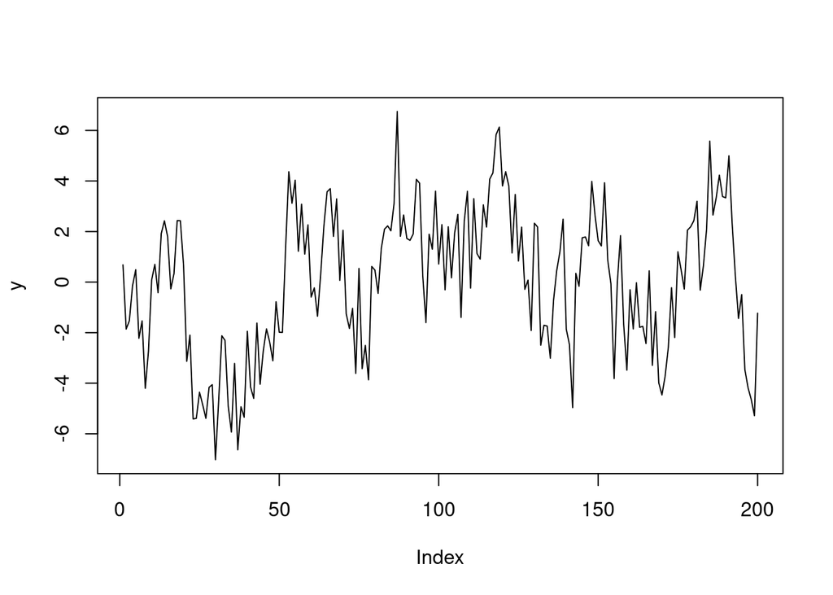

```r
plot(ts, type="l", ylab="y")
```

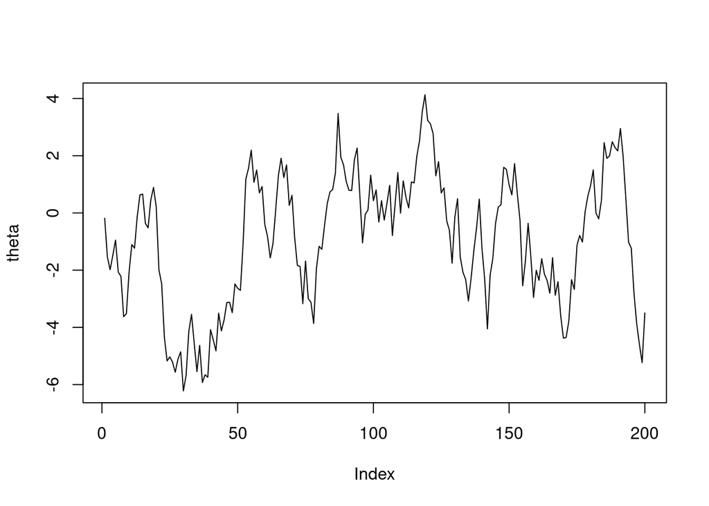

```r
plot(theta, type="l")
```

# (b)

Consider an AR(p) model in the form of $\mathbf{y}=\mathbf{F}'\mathbf{\beta}+\mathbf{\epsilon}, \mathbf{\epsilon} \sim N(\mathbf{0}, v\mathbf{I})$. Here $\mathbf{\phi}=\mathbf{\beta}$.

The reference prior is $p(\mathbf{\beta}, v) \propto 1/v$.

The likelihood is
$$p(\mathbf{y}|\mathbf{\beta}, v, \mathbf{F}) \propto (2 \pi v)^{-n/2} exp (-Q (y, \mathbf{\beta})/2v)$$
, where
$$Q(\mathbf{\beta}, \mathbf{y})=(\mathbf{y}-\mathbf{F}'\mathbf{\beta})'(\mathbf{y}-\mathbf{F}'\mathbf{\beta})=(\mathbf{\beta}-\hat{\mathbf{\beta}})'(\mathbf{F}\mathbf{F}')(\mathbf{\beta}-\hat{\mathbf{\beta}})+R$$
, with $\hat{\mathbf{\beta}} = (\mathbf{F}\mathbf{F}')^{-1}\mathbf{F}\mathbf{y}$ and $R=(\mathbf{y}-\mathbf{F}'\hat{\mathbf{\beta}})'(\mathbf{y}-\mathbf{F}'\hat{\mathbf{\beta}})$, and $s^2=\frac{R}{n-p}$.

The posteriors are therefore the following.
$$(v|\mathbf{y}, \mathbf{F}) \sim IG (\frac {(n-p)}{2},\frac {(n-p)s^2}{2})$$
$$(\mathbf{\beta}|v, \mathbf{y}, \mathbf{F}) \sim N(\hat{\beta}, v(FF')^{-1})$$
I fitted AR(1) to AR(15) models by finding $\hat{\mathbf{\beta}}$ and $s^2$. I then calculated the AIC and BIC scores using the corresponsing $s^2$ following:
$$AIC=2p+n\log(s^2_p)$$
$$BIC=\log(n)p+n\log(s^2_p)$$

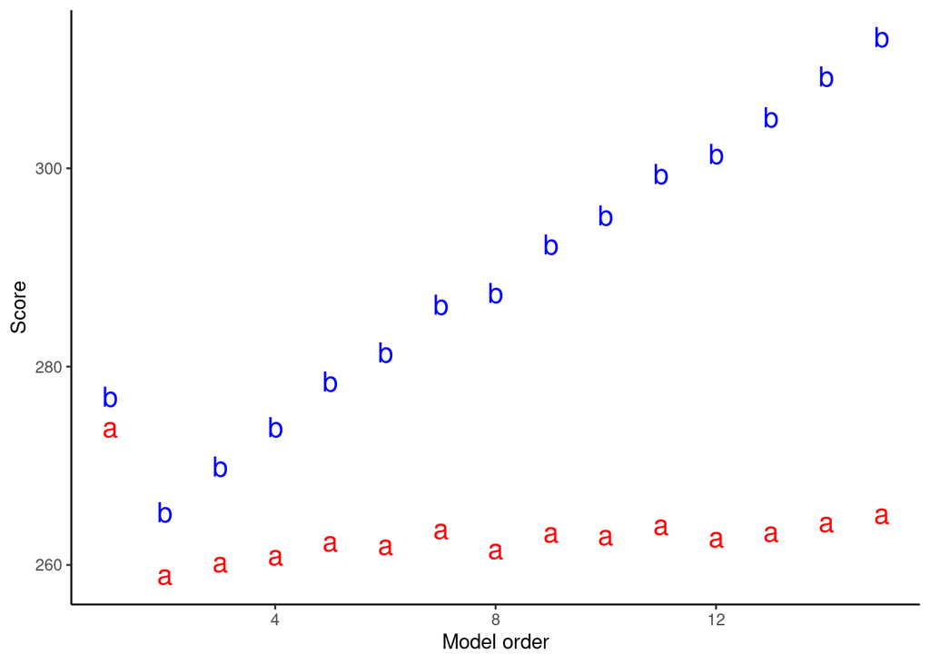

```r
AIC_p<-rep(NA, 15)
BIC_p<-rep(NA, 15)

n<-length(ts)

# infer parameters
for(p in 1:15) {
  y<-ts[(p+1):(n)]
  y_prev<-matrix(NA, ncol = n-p, nrow = p)
  for(i in 1:p) {
    y_prev[i,]<-ts[(p-i+1):(n-i)]
  }

  beta_hat<-solve(y_prev %*% t(y_prev))%*%y_prev%*%y
  resid<-y-t(y_prev)%*% beta_hat
  s_square<-(t(resid) %*%(resid))/(n-p)

  AIC_p[[p]]<-2*(p)+(n-p)*log(s_square)
  BIC_p[[p]]<-log(n-p)*p+(n-p)*log(s_square)
}

AICBIC<-data.frame(p=1:15,AIC=AIC_p, BIC=BIC_p)
ggplot(AICBIC)+
  geom_point(aes(x=p, y=AIC), col="red", pch="a", cex=5)+
  geom_point(aes(x=p, y=BIC), col="blue", pch="b", cex=5)+
  ylab("Score")+
  xlab("Model order")+
  theme_classic()
```

Both AIC and BIC were the lowest at model order 2, so I chose to fit an AR(2) model for the rest of this problem.

Using the $\hat{\mathbf{\beta}}$ and $s^2$ from AR(2), I generated 500 samples from the posteriors of $v$ and then from $\mathbf{\phi}$.

```r
p<-2
# Reference prior
y<-ts[(p+1):(n)]
y_prev<-matrix(NA, ncol = n-p, nrow = p)
for(i in 1:p) {
  y_prev[i,]<-ts[(p-i+1):(n-i)]
}

beta_hat<-solve(y_prev %*% t(y_prev))%*%y_prev%*%y
resid<-y-t(y_prev)%*% beta_hat
s_square<-(t(resid) %*%(resid))/(n-p)

v_posterior<-LaplacesDemon::rinvgamma(500, (n-p)/2, (n-p)*s_square/2)
phi_posterior<-matrix(NA, nrow=500, ncol=p)
for (i in 1:500) {
  phi_posterior[i,]<-MASS::mvrnorm(1, mu = beta_hat, Sigma = v_posterior[i]*solve(y_prev %*% t(y_prev)))
}
```

Here are summaries of the inferred model parameters. The variance of the AR process is characterized by the posterior distribution of $v$. The solid blue lines denote the mean and the dashed blue lines denote the 95% credible intervals.

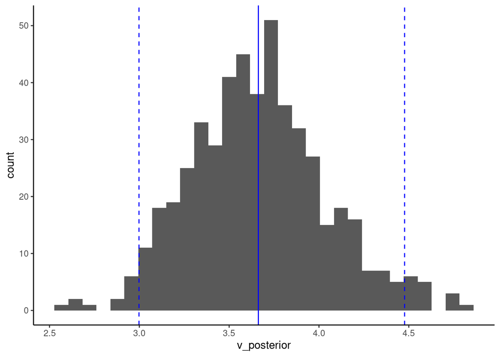

```r
v_posterior_df<-data.frame(v_posterior)

v_posterior_summary <- v_posterior_df %>%
  summarize(mean=mean(v_posterior, na.rm=T),
            lower=quantile(v_posterior, prob=0.025, na.rm=T),
            upper=quantile(v_posterior, prob=0.975, na.rm=T))

ggplot(v_posterior_df, aes(x=v_posterior))+
  geom_histogram()+
  geom_vline(data=v_posterior_summary, aes(xintercept=mean), col="blue")+
  geom_vline(data=v_posterior_summary, aes(xintercept=lower), col="blue", lty=2)+
  geom_vline(data=v_posterior_summary, aes(xintercept=upper), col="blue", lty=2)+
  theme_classic()
```

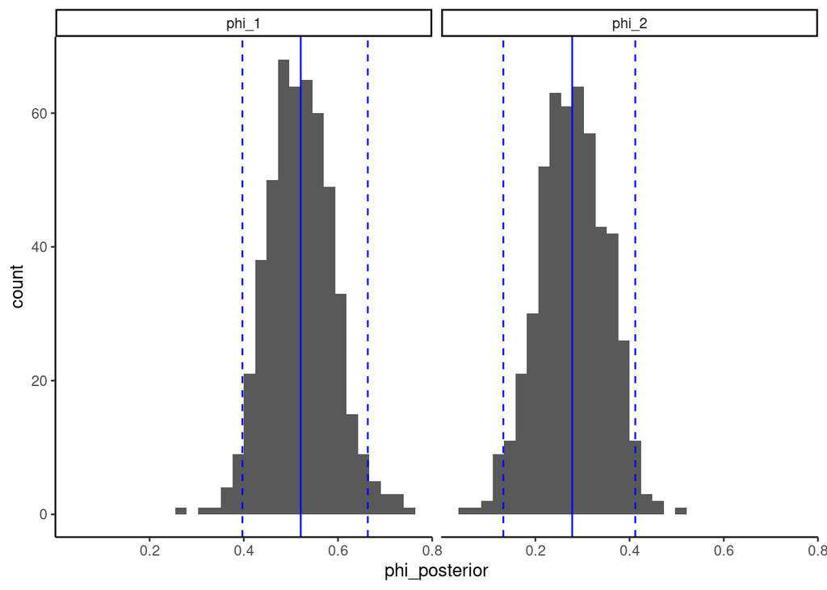

```r
phi_posterior_df<-data.frame(phi_posterior) %>%
  rename(phi_1=X1, phi_2=X2) %>%
  gather(value="phi_posterior")

phi_posterior_summary <- phi_posterior_df %>%
  group_by(key) %>%
  summarize(mean=mean(phi_posterior, na.rm=T),
            lower=quantile(phi_posterior, prob=0.025, na.rm=T),
            upper=quantile(phi_posterior, prob=0.975, na.rm=T))

ggplot(phi_posterior_df, aes(x=phi_posterior))+
  geom_histogram()+
  geom_vline(data=phi_posterior_summary, aes(xintercept=mean), col="blue")+
  geom_vline(data=phi_posterior_summary, aes(xintercept=lower), col="blue", lty=2)+
  geom_vline(data=phi_posterior_summary, aes(xintercept=upper), col="blue", lty=2)+
  facet_wrap(. ~ key)+
  theme_classic()
```

I then used the $\mathbf{\phi}$ sampled from the posterior to calculate the reciprocal roots. The code below allows both complex and reciprocal roots, but after checking, I found all reciprocal roots to be real.

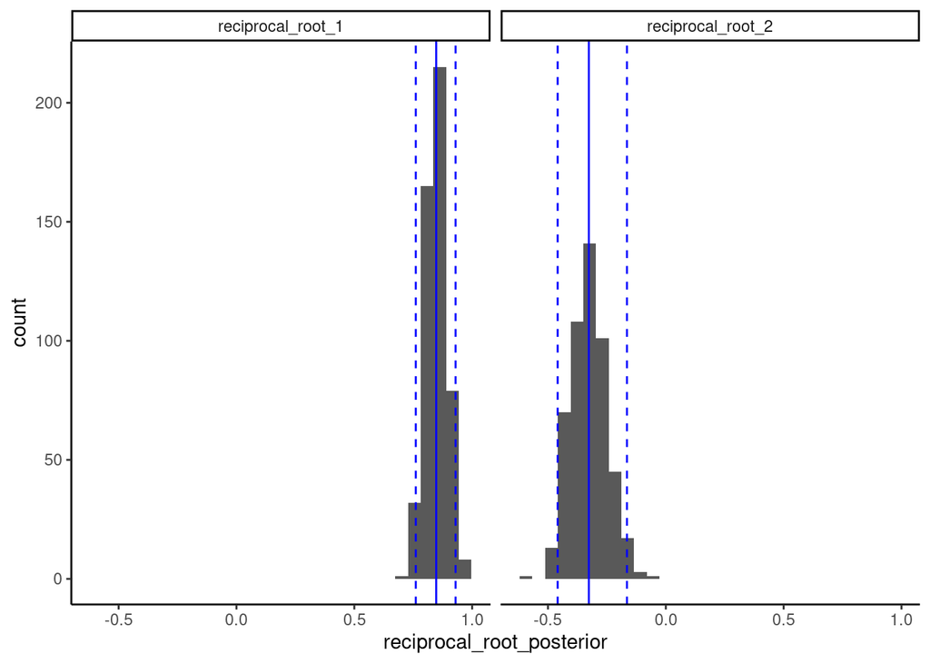

```r
real_modulus_posterior<-data.frame(reciprocal_root_1=rep(NA, 500), reciprocal_root_2=rep(NA, 500))

for(i in 1:500) {
  poly_coef<-c(1, -phi_posterior[i,])
  recroots<-data.frame(recroot=1/polyroot(poly_coef)) %>%
    mutate(im=Im(recroot)) %>%
    mutate(ReCom=if_else(abs(im)>0.0000000001, "Complex", "Real")) %>%
    mutate(modulus=if_else(ReCom=="Complex", Mod(recroot), Re(recroot))) %>%
    mutate(arg=abs(Arg(recroot))) %>%
    mutate(wavelength=2*pi/arg) %>%
    arrange(desc(wavelength)) %>%
    arrange(ReCom) %>%
    distinct(round(modulus, digits = 10),.keep_all = T)
  real_modulus<-unlist(recroots %>% filter(ReCom=="Real") %>% select(modulus))
  length(real_modulus)<-2
  real_modulus_posterior[i,]<-real_modulus
}

modulus_posterior_df<-real_modulus_posterior %>%
  gather(value="reciprocal_root_posterior")
modulus_posterior_summary <- modulus_posterior_df%>%
  group_by(key) %>%
  summarize(mean=mean(reciprocal_root_posterior, na.rm=T),
            lower=quantile(reciprocal_root_posterior, prob=0.025, na.rm=T),
            upper=quantile(reciprocal_root_posterior, prob=0.975, na.rm=T))
ggplot(modulus_posterior_df, aes(x=reciprocal_root_posterior))+
  geom_histogram()+
  geom_vline(data=modulus_posterior_summary, aes(xintercept=mean), col="blue")+
  geom_vline(data=modulus_posterior_summary, aes(xintercept=lower), col="blue", lty=2)+
  geom_vline(data=modulus_posterior_summary, aes(xintercept=upper), col="blue", lty=2)+
  facet_wrap(. ~ key)+
  theme_classic()
```

I concluded that the time series can be fitted with a AR(2) model, with two real AR coefficients (0.52 and 0.28) and variance 3.66.

# (c)

Using the *arima* function in R, I fitted ARMA($p$, $q$) models, with $p=1, ..., 5$ and $q=1, ..., 5$. The AIC values are shown in the following grids.

```r
AIC_arma<-matrix(NA, nrow=5, ncol=5)
for (p in 1:5) {
  for (q in 1:5) {
    AIC_arma[p, q]<-AIC(arima(ts, order = c(p, 0, q), include.mean = F))
  }
}
```

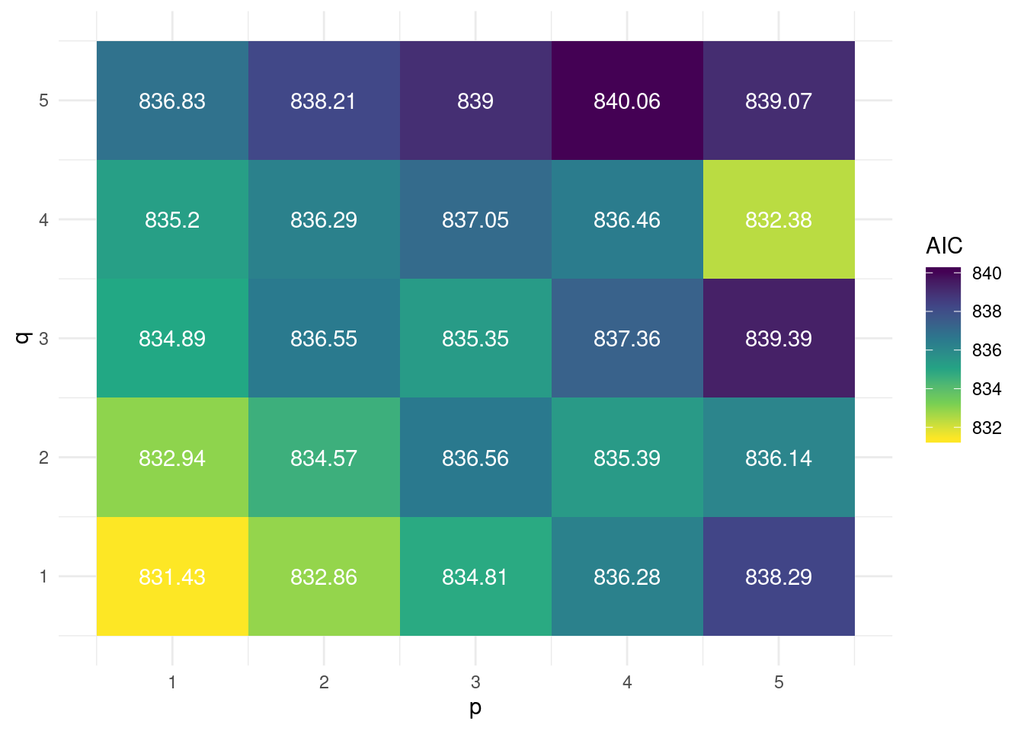

```r
AIC_arma_df<-data.frame(AIC_arma) %>%
  mutate(p=c(1:5)) %>%
  gather("q", "AIC",-p) %>%
  mutate(q=substr(q, 2,2)) %>%
  mutate(q=as.numeric(q))
ggplot(AIC_arma_df, aes(x=p, y=q, fill=AIC, label=round(AIC, 2)))+
  geom_tile()+
  geom_text(color="white")+
  scale_fill_viridis_c(direction = -1)+
  theme_minimal()
```

It was shown that ARMA(1, 1) had the lowest AIC. I therefore estimated the AR and MA coefficients, as well as the variance.

```r
arima(ts, order = c(1, 0, 1), include.mean = F)
```

```
##
## Call:
## arima(x = ts, order = c(1, 0, 1), include.mean = F)
##
## Coefficients:
##          ar1      ma1
##       0.8803  -0.3550
## s.e.  0.0422   0.0809
##
## sigma^2 estimated as 3.614:  log likelihood = -412.72,  aic = 831.43
```

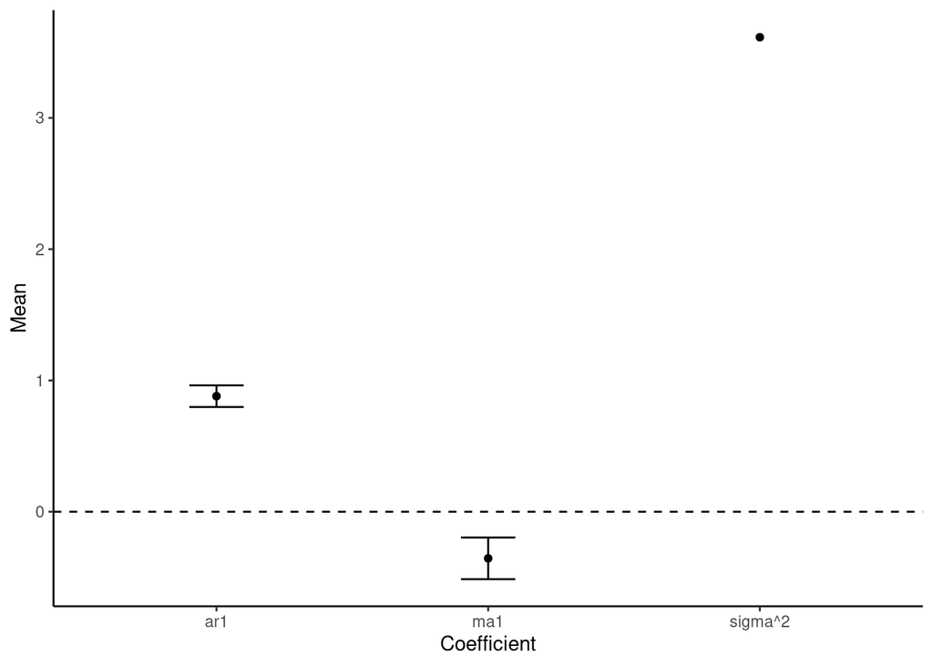

```r
arma_coef<-coef(arima(ts, order = c(1, 0, 1), include.mean = F))
arma_coef_sd<-sqrt(diag(vcov(arima(ts, order = c(1, 0, 1), include.mean = F))))
sigma2<-arima(ts, order = c(1, 0, 1), include.mean = F)$sigma2
arma_summary<-data.frame(Coefficient=c(names(arma_coef), "sigma^2"), Mean=c(arma_coef, sigma2), SD=c(arma_coef_sd, NA))
ggplot(arma_summary)+
  geom_point(aes(x=Coefficient, y=Mean))+
  geom_errorbar(aes(x=Coefficient, ymin=Mean-1.96*SD,ymax=Mean+1.96*SD), width=0.2, na.rm = T)+
  geom_hline(yintercept = 0, lty=2)+
  theme_classic()
```

# (d)

The new AR coefficient is the first reciprocal root, $\alpha_1$, according to the new characteristic equation $\Phi^*(u)=1-\alpha_1 u=0$.

To invert the second AR component to a MA component, I used the following algorithm, following Prado & West (2010, pp. 68).

1. Initialize the algorithm by setting $\psi^*_1=0$.
2. Update $\psi^*_1=\psi^*_1+\alpha_2$.

I did the inversion for all 500 sets of AR coefficients sampled from the posterior.

I here summarize the AR and MA coefficients.

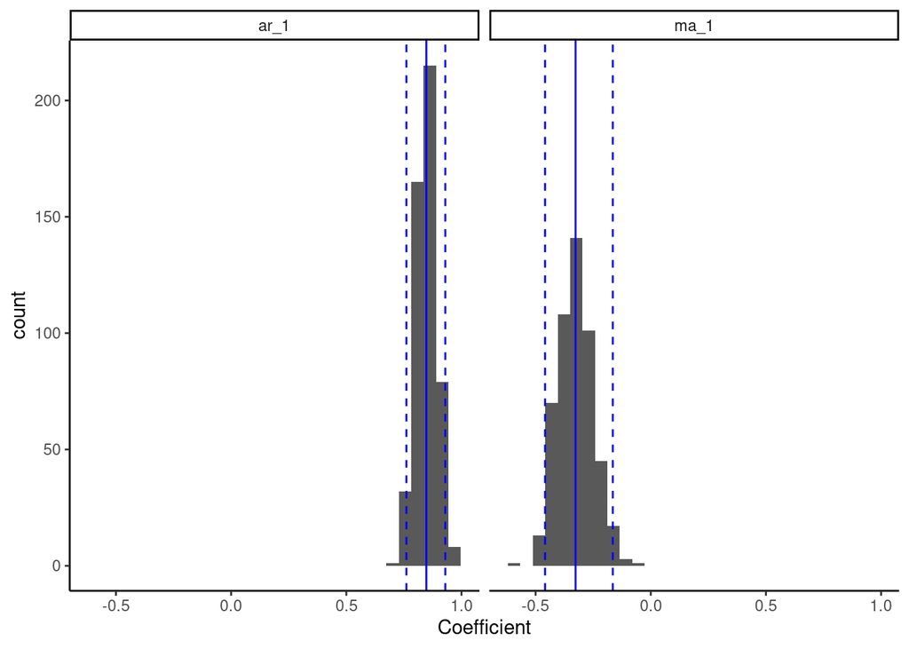

```r
p<-2
q<-1
psi<-matrix(0, nrow=500, ncol=q)
for (k in 1:500) {
  for (i in 2:p) {
    psi[k,1]<-psi[k,1]+real_modulus_posterior[k, i]
  }
}

arma_coef_df<-data.frame(ar_1=real_modulus_posterior[,1], ma_1=psi[,1]) %>%
  gather(value="Coefficient")
arma_coef_df_summary<-arma_coef_df %>%
  group_by(key) %>%
  summarize(mean=mean(Coefficient, na.rm=T),
            lower=quantile(Coefficient, prob=0.025, na.rm=T),
            upper=quantile(Coefficient, prob=0.975, na.rm=T))

ggplot(data.frame(arma_coef_df), aes(x=Coefficient))+
  geom_histogram()+
  geom_vline(data=arma_coef_df_summary, aes(xintercept=mean), col="blue")+
  geom_vline(data=arma_coef_df_summary, aes(xintercept=lower), col="blue", lty=2)+
  geom_vline(data=arma_coef_df_summary, aes(xintercept=upper), col="blue", lty=2)+
  facet_wrap(. ~ key)+
  theme_classic()
```

The estimates are highly similar to those obtained with the *arima* function.